# Introduction_to_bioconductor-Note3

Sung

9/8/2020

## Getting data into Bioconductor

Bioconductor has a list of convenient data container such as expression sets, summarized experiments, and GRanges. But how do we get data into Bioconductor.

##### For example, microarray data since it is easiest to discuss.

In microarray, you typically get raw data from the microarray vendor or microarray scaner. Two examplar vendors are Affymetrix and Illumina. Bioconductor has a couple of packages for providing supports for parsing of these vendor-specific file format.

- affyio
- affxparser
- illuminaio

These packages are low-level. Many analysis specific packages supports file import into useful datastructures. For example,

- affy for Affymetrix Gene Expression data (old packages).
- oligo for Affymetrix and Nimblegen expression and SNP array data (newer version)
- lumi for illumina array
- minifi for illumina DNA methylation array

##### Other application area is high-throughput sequencing

Raw reads are provided in FASTQ format. The next step after the profiles is alignment to the reference genome using Bowtie, MEQ, BWA, GSNAP, or TopHat.

For storing aligned reads, BAM or SAM format.

FASTQ, BAM and SAM files are raw files. After BAM files, it is very domain specific. It is different sequencing to chip sequencing to DNA sequencing. Within the domain depends a lot on what to do with data and what pipeline to run the data. If RNA sequencing, maybe interested in getting gene level counts. Or simply do assembly with Cufflink.

The type of data produced is quite different from each other. So we need a set of versatile tool to read different file formats and put them into what we want.

For next generation sequencing, rtracklayer package is very useful. It supports BigWig, and BigBed files.

We also have VCF files after genotyping within BCF format. A VariantAnnotation package can be used to deal with this file.

Finally, we have text files. A lot of pipelines produce text files and it is for users to write a parser to read these text files.

A versatile tool to read tab-delimited text files is read.table(). The readr package that has a set of versatile functions and data.table package also has a fast function.

Popularly available datasets can be obtained from databases. The data can be downloaded by

- GEOquery
- SRAdb
- ArrayExpress

## Short Read

The short read package contains two different functionalities for reading raw sequencing reads, typically in form of FASTQ. It also read in aligned reads (out-dated, use rsamtools).

```r
#BiocManager::install("ShortRead")
library(ShortRead)
fastqDir <- system.file("extdata","E-MTAB-1147", package="ShortRead")
fastqPath <- list.files(fastqDir,pattern=".fastq.gz$", full=TRUE)[1]
fastqPath
```

```
## [1] "/Library/Frameworks/R.framework/Versions/3.6/Resources/library/ShortRead/extdata/E-MTAB-1147/ERR127302_1_subset.fastq.gz"
```

```r
reads <- readFastq(fastqPath)
reads
```

```
## class: ShortReadQ
## length: 20000 reads; width: 72 cycles
```

20,000 reads and each read is 72 pages long.

Another way,

```r
fqFile <- FastqFile(fastqPath)
fqFile
```

```
## class: FastqFile
## path: /Library/Frameworks/R.framework/Versions/3..../ERR127302_1_subset.fastq.gz
## isOpen: FALSE
```

```r
reads <- readFastq(fqFile)
```

Sometimes we need this step if we are reading smaller chunk of files.

How do we access information inside of FastqFile? - Fastqfile contains reads, base quality, and read names.

We access sread() function to access DNA information, quality() to access base quality, and id() gives the read names.

```r
sread(reads)[1:2]
```

```
##   A DNAStringSet instance of length 2
##     width seq
## [1]    72 GTCTGCTGTATCTGTGTCGGCTGTCTCGCGGGAC...GTCAATGAAGGCCTGGAATGTCACTACCCCCAG
## [2]    72 CTAGGGCAATCTTTGCAGCAATGAATGCCAATGG...CAGTGGCTTTTGAGGCCAGAGCAGACCTTCGGG
```

```r
quality(reads)[1:2]
```

```
## class: FastqQuality
## quality:
##   A BStringSet instance of length 2
##     width seq
## [1]    72 HHHHHHHHHHHHHHHHHHHHEBDBB?B:BBGG<D...ABFEFBDBD@DDECEE3>:?;@@@>?=BAB?##
## [2]    72 IIIIHIIIGIIIIIIIHIIIIEGBGHIIIIHGII...IIIHIIIHIIIIIGIIIEGIIGBGE@DDGGGIG
```

```r
id(reads)[1:2]
```

```
##   A BStringSet instance of length 2
##     width seq
## [1]    53 ERR127302.8493430 HWI-EAS350_0441:1:34:16191:2123#0/1
## [2]    53 ERR127302.21406531 HWI-EAS350_0441:1:88:9330:2587#0/1
```

Quality values are BStringSet and they encode qualities on fret scale. They are intergers between 0 and 40. This is done for compression. For quality accessment, we need to convert letters to numbers by coalescing the quality scores into a matrix.

```r
as(quality(reads), "matrix")[1:2,1:10]
```

```
##      [,1] [,2] [,3] [,4] [,5] [,6] [,7] [,8] [,9] [,10]
## [1,]   39   39   39   39   39   39   39   39   39    39
## [2,]   40   40   40   40   39   40   40   40   38    40
```

This score gives you how likely the reported base is correct or chance of sequencing error.

## Rsamtools

Rsamtools library interface with high throughput sequencing library. This package deals with SAM and BAM format. SAM is a text file format for representing aligned reads. BAM is a binary version of SAM (fast and convenient).

```r
#BiocManager::install("Rsamtools")
library(Rsamtools)
```

First, we need to instantiate BAM file.

```r
bamPath <- system.file("extdata", "ex1.bam", package="Rsamtools")
bamPath
```

```
## [1] "/Library/Frameworks/R.framework/Versions/3.6/Resources/library/Rsamtools/extdata/ex1.bam"
```

```r
bamFile <- BamFile(bamPath)
bamFile
```

```
## class: BamFile
## path: /Library/Frameworks/R.framework/Versions/3.6/Resources/library/.../ex1.bam
## index: /Library/Frameworks/R.framework/Versions/3.6/Resources/lib.../ex1.bam.bai
## isOpen: FALSE
## yieldSize: NA
## obeyQname: FALSE
## asMates: FALSE
## qnamePrefixEnd: NA
## qnameSuffixStart: NA
```

Without reading the file, we can access seqinfo

```r
seqinfo(bamFile)
```

```
## Seqinfo object with 2 sequences from an unspecified genome:
##   seqnames seqlengths isCircular genome
##   seq1           1575         NA   <NA>
##   seq2           1584         NA   <NA>
```

We can read BAM file using scanBam()

```r
aln <- scanBam(bamFile)
length(aln)
```

```
## [1] 1
```

```r
class(aln)
```

```
## [1] "list"
```

```r
names(aln)
```

[output not shown]

No information so far, because it is one file.

```r
aln <- aln[[1]]
names(aln)
```

```
##  [1] "qname"  "flag"   "rname"  "strand" "pos"    "qwidth" "mapq"   "cigar"
##  [9] "mrnm"   "mpos"   "isize"  "seq"    "qual"
```

```r
lapply(aln, function(xx) xx[1])
```

```
## $qname
## [1] "B7_591:4:96:693:509"
##
## $flag
## [1] 73
##
## $rname
## [1] seq1
## Levels: seq1 seq2
##
## $strand
## [1] +
## Levels: + - *
##
## $pos
## [1] 1
##
## $qwidth
## [1] 36
##
## $mapq
## [1] 99
##
## $cigar
## [1] "36M"
##
## $mrnm
## [1] <NA>
## Levels: seq1 seq2
##
## $mpos
## [1] NA
##
## $isize
## [1] NA
##
## $seq
##   A DNAStringSet instance of length 1
##     width seq
## [1]    36 CACTAGTGGCTCATTGTAAATGTGTGGTTTAACTCG
##
## $qual
##   A PhredQuality instance of length 1
##     width seq
## [1]    36 <<<<<<<<<<<<<<<;<<<<<<<<<5<<<<<;:<;7
```

Each read can be aligned to multiple places in genome, or can contain multiple alignments, or can be associated with multiple alignments. It is also possible for BAM files to contain unaligned reads.

Read BAM files in smaller chunks. - read only parts of BAM file. - read customized ranges.

```r
yieldSize(bamFile) <- 1
open(bamFile)
scanBam(bamFile)[[1]]$seq # every read is different so we can continue until it ends.
```

```
##   A DNAStringSet instance of length 1
##     width seq
## [1]    36 CACTAGTGGCTCATTGTAAATGTGTGGTTTAACTCG
```

```r
close(bamFile)
yieldSize(bamFile) <- NA
```

Another way of reading is by pre-specified regions of genome, or pre-specified components of the file.

```r
gr <- GRanges(seqnames="seq2", ranges=IRanges(start=c(100,1000), end=c(1500,2000)))
```

What we do is we set up a ScanBamParam that encodes a query to the BAM file.

```r
params <- ScanBamParam(which=gr, what=scanBamWhat())
aln <- scanBam(bamFile, param=params)
names(aln)
```

```
## [1] "seq2:100-1500"  "seq2:1000-2000"
```

```r
head(aln[[1]]$pos)
```

```
## [1] 66 68 68 72 73 77
```

Reading multiple files can be done through BamViews().

```r
bamView <- BamViews(bamPath)
bamView
```

```
## BamViews dim: 0 ranges x 1 samples
## names: ex1.bam
## detail: use bamPaths(), bamSamples(), bamRanges(), ...
```

```r
aln <- scanBam(bamView)
names(aln)
```

```
## [1] "ex1.bam"
```

```r
names(aln[[1]][[1]])
```

```
##  [1] "qname"  "flag"   "rname"  "strand" "pos"    "qwidth" "mapq"   "cigar"
##  [9] "mrnm"   "mpos"   "isize"  "seq"    "qual"
```

We can set ranges on BamView

```r
bamRanges(bamView) = gr
aln <- scanBam(bamView)
aln[[1]]
```

```
## $`seq2:100-1500`
## $`seq2:100-1500`$qname
##    [1] "EAS56_57:2:206:873:186"        "EAS1_93:6:238:514:194"
##    [3] "EAS56_57:3:285:489:327"        "EAS54_67:1:15:381:715"
##    [5] "EAS114_32:6:199:818:124"       "EAS56_59:3:182:1002:639"
##    [7] "EAS221_1:2:3:945:2005"         "B7_591:5:254:542:848"
##    [9] "EAS1_95:4:71:517:742"          "EAS1_105:8:254:617:73"
##   [11] "EAS114_45:2:13:1507:1146"      "EAS139_11:5:32:686:735"
##   [13] "EAS56_57:3:112:729:591"        "EAS114_39:5:17:1222:783"
##   [15] "EAS188_7:6:46:122:479"         "B7_593:2:313:531:169"
##   [17] "EAS51_62:6:148:170:895"        "EAS114_39:6:34:380:815"
##   [19] "EAS51_64:6:210:809:735"        "EAS54_81:8:40:925:442"
##   [21] "EAS54_71:4:169:256:888"        "EAS56_65:8:117:156:84"
##   [23] "EAS114_26:1:35:522:294"        "EAS114_45:3:41:653:1568"
##   [25] "EAS114_28:7:178:276:693"       "EAS54_73:7:223:440:667"
```

[output cut: 2980 more lines]

For summary,

```r
quickBamFlagSummary(bamFile)
```

```
##                                 group |    nb of |    nb of | mean / max
##                                    of |  records |   unique | records per
##                               records | in group |   QNAMEs | unique QNAME
## All records........................ A |     3307 |     1699 | 1.95 / 2
##   o template has single segment.... S |        0 |        0 |   NA / NA
##   o template has multiple segments. M |     3307 |     1699 | 1.95 / 2
##       - first segment.............. F |     1654 |     1654 |    1 / 1
##       - last segment............... L |     1653 |     1653 |    1 / 1
##       - other segment.............. O |        0 |        0 |   NA / NA
##
## Note that (S, M) is a partitioning of A, and (F, L, O) is a partitioning of M.
## Indentation reflects this.
##
## Details for group M:
##   o record is mapped.............. M1 |     3271 |     1699 | 1.93 / 2
##       - primary alignment......... M2 |     3271 |     1699 | 1.93 / 2
##       - secondary alignment....... M3 |        0 |        0 |   NA / NA
##   o record is unmapped............ M4 |       36 |       36 |    1 / 1
##
## Details for group F:
##   o record is mapped.............. F1 |     1641 |     1641 |    1 / 1
##       - primary alignment......... F2 |     1641 |     1641 |    1 / 1
##       - secondary alignment....... F3 |        0 |        0 |   NA / NA
##   o record is unmapped............ F4 |       13 |       13 |    1 / 1
##
## Details for group L:
##   o record is mapped.............. L1 |     1630 |     1630 |    1 / 1
##       - primary alignment......... L2 |     1630 |     1630 |    1 / 1
##       - secondary alignment....... L3 |        0 |        0 |   NA / NA
##   o record is unmapped............ L4 |       23 |       23 |    1 / 1
```

## oligo

Oligo package for pre-processing and handling affymetrix and nimblegene microarrays. - Gene expression micro-arrays - SNP micro-arrays

This package is a continuation of earlier package called Affy.

```r
#BiocManager::install("oligo")
library(oligo)
library(GEOquery)
```

We will use the dataset deposited as GEO accession number "GSE38792". In this dataset, the experimenters profiled fat biopsies from two different conditions: 10 patients with obstructive sleep apnea (OSA) and 8 healthy controls.

We want to look at specific GEOfile and CEL files. These are not standard file from GEO, it is a supplementary.

On Affymetrix array, probes are typically 25 bases long. This means that the probes are not very specific. To compensate this, you measure one specific RNA with multiple probes all at the same target. This multiple probes are grouped into probe sets.

```r
#getGEOSuppFiles("GSE38792")
list.files("GSE38792")
```

```
## [1] "CEL"              "GSE38792_RAW.tar"
```

```r
untar("GSE38792/GSE38792_RAW.tar", exdir="GSE38792/CEL")
list.files("GSE38792/CEL")
```

```
##  [1] "GSM949164_Control1.CEL.gz" "GSM949166_Control2.CEL.gz"
##  [3] "GSM949168_Control3.CEL.gz" "GSM949169_Control4.CEL.gz"
##  [5] "GSM949170_Control5.CEL.gz" "GSM949171_Control6.CEL.gz"
##  [7] "GSM949172_Control7.CEL.gz" "GSM949173_Control8.CEL.gz"
##  [9] "GSM949174_OSA1.CEL.gz"     "GSM949175_OSA2.CEL.gz"
## [11] "GSM949176_OSA3.CEL.gz"     "GSM949177_OSA4.CEL.gz"
## [13] "GSM949178_OSA5.CEL.gz"     "GSM949179_OSA6.CEL.gz"
## [15] "GSM949180_OSA7.CEL.gz"     "GSM949181_OSA8.CEL.gz"
## [17] "GSM949182_OSA9.CEL.gz"     "GSM949183_OSA10.CEL.gz"
```

Then, we obtain list of CEL files with full name. Construct a vector of filenames and feed it to read.celfiles()

```r
celfiles <- list.files("GSE38792/CEL",full=TRUE)
celfiles
```

```
##  [1] "GSE38792/CEL/GSM949164_Control1.CEL.gz"
##  [2] "GSE38792/CEL/GSM949166_Control2.CEL.gz"
##  [3] "GSE38792/CEL/GSM949168_Control3.CEL.gz"
##  [4] "GSE38792/CEL/GSM949169_Control4.CEL.gz"
##  [5] "GSE38792/CEL/GSM949170_Control5.CEL.gz"
##  [6] "GSE38792/CEL/GSM949171_Control6.CEL.gz"
##  [7] "GSE38792/CEL/GSM949172_Control7.CEL.gz"
##  [8] "GSE38792/CEL/GSM949173_Control8.CEL.gz"
##  [9] "GSE38792/CEL/GSM949174_OSA1.CEL.gz"
## [10] "GSE38792/CEL/GSM949175_OSA2.CEL.gz"
## [11] "GSE38792/CEL/GSM949176_OSA3.CEL.gz"
## [12] "GSE38792/CEL/GSM949177_OSA4.CEL.gz"
## [13] "GSE38792/CEL/GSM949178_OSA5.CEL.gz"
## [14] "GSE38792/CEL/GSM949179_OSA6.CEL.gz"
## [15] "GSE38792/CEL/GSM949180_OSA7.CEL.gz"
## [16] "GSE38792/CEL/GSM949181_OSA8.CEL.gz"
## [17] "GSE38792/CEL/GSM949182_OSA9.CEL.gz"
## [18] "GSE38792/CEL/GSM949183_OSA10.CEL.gz"
```

```r
rawData <- read.celfiles(celfiles)
```

```
## Platform design info loaded.
```

[output not shown]

```r
rawData
```

```
## GeneFeatureSet (storageMode: lockedEnvironment)
## assayData: 1102500 features, 18 samples
##   element names: exprs
## protocolData
##   rowNames: GSM949164_Control1.CEL.gz GSM949166_Control2.CEL.gz ...
##     GSM949183_OSA10.CEL.gz (18 total)
##   varLabels: exprs dates
##   varMetadata: labelDescription channel
## phenoData
##   rowNames: GSM949164_Control1.CEL.gz GSM949166_Control2.CEL.gz ...
##     GSM949183_OSA10.CEL.gz (18 total)
##   varLabels: index
##   varMetadata: labelDescription channel
## featureData: none
## experimentData: use 'experimentData(object)'
## Annotation: pd.hugene.1.0.st.v1
```

This is in the form of an GeneFeatureSet, which is an ExpressionSet-like container.

```r
getClass("GeneFeatureSet")
```

```
## Class "GeneFeatureSet" [package "oligoClasses"]
##
## Slots:
##
## Name:        manufacturer      intensityFile          assayData
## Class:          character          character          AssayData
##
## Name:           phenoData        featureData     experimentData
## Class: AnnotatedDataFrame AnnotatedDataFrame              MIAxE
##
## Name:          annotation       protocolData  .__classVersion__
## Class:          character AnnotatedDataFrame           Versions
##
## Extends:
## Class "FeatureSet", directly
## Class "NChannelSet", by class "FeatureSet", distance 2
## Class "eSet", by class "FeatureSet", distance 3
## Class "VersionedBiobase", by class "FeatureSet", distance 4
## Class "Versioned", by class "FeatureSet", distance 5
```

Expression data are raw intensity measurement from the scanner. Micro-array scanner is typically 16-bit scanner and you get results between 0 and 2^16.

```r
exprs(rawData)[1:4,1:3]
```

```
##   GSM949164_Control1.CEL.gz GSM949166_Control2.CEL.gz GSM949168_Control3.CEL.gz
## 1                      9411                      9917                      8891
## 2                       255                       200                       181
## 3                      9171                      9202                      9266
## 4                       229                       220                       202
```

```r
max(exprs(rawData)) # to check max or limit.
```

```
## [1] 65534
```

Usually, we want to log transform these dataset. But first we are going to clean data.

```r
filename <- sampleNames(rawData)
pData(rawData)$filename <- filename
sampleNames <- sub(".*_","",filename)
sampleNames <- sub(".CEL.gz$","",sampleNames)
sampleNames
```

```
##  [1] "Control1" "Control2" "Control3" "Control4" "Control5" "Control6"
##  [7] "Control7" "Control8" "OSA1"     "OSA2"     "OSA3"     "OSA4"
## [13] "OSA5"     "OSA6"     "OSA7"     "OSA8"     "OSA9"     "OSA10"
```

```r
sampleNames(rawData) <- sampleNames
pData(rawData)$group <- ifelse(grepl("^OSA", sampleNames(rawData)),"OSA","Control")
pData(rawData)
```

```
##          index                  filename   group
## Control1     1 GSM949164_Control1.CEL.gz Control
## Control2     2 GSM949166_Control2.CEL.gz Control
## Control3     3 GSM949168_Control3.CEL.gz Control
## Control4     4 GSM949169_Control4.CEL.gz Control
## Control5     5 GSM949170_Control5.CEL.gz Control
## Control6     6 GSM949171_Control6.CEL.gz Control
## Control7     7 GSM949172_Control7.CEL.gz Control
## Control8     8 GSM949173_Control8.CEL.gz Control
## OSA1         9     GSM949174_OSA1.CEL.gz     OSA
## OSA2        10     GSM949175_OSA2.CEL.gz     OSA
## OSA3        11     GSM949176_OSA3.CEL.gz     OSA
## OSA4        12     GSM949177_OSA4.CEL.gz     OSA
## OSA5        13     GSM949178_OSA5.CEL.gz     OSA
## OSA6        14     GSM949179_OSA6.CEL.gz     OSA
## OSA7        15     GSM949180_OSA7.CEL.gz     OSA
## OSA8        16     GSM949181_OSA8.CEL.gz     OSA
## OSA9        17     GSM949182_OSA9.CEL.gz     OSA
## OSA10       18    GSM949183_OSA10.CEL.gz     OSA
```

Before any normalization, we need to look at the need of such transformation.

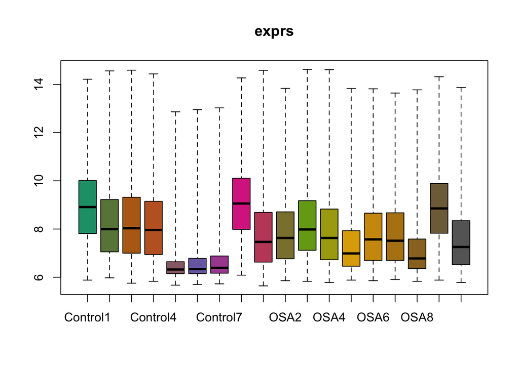

```r
boxplot(rawData,"all")
```

#### Normalization

For Affymetrix gene expression data, RMA method is recommended.

```r
normData <- rma(rawData)
```

```
## Background correcting
## Normalizing
## Calculating Expression
```

```r
normData
```

```
## ExpressionSet (storageMode: lockedEnvironment)
## assayData: 33297 features, 18 samples
##   element names: exprs
## protocolData
##   rowNames: Control1 Control2 ... OSA10 (18 total)
##   varLabels: exprs dates
##   varMetadata: labelDescription channel
## phenoData
##   rowNames: Control1 Control2 ... OSA10 (18 total)
##   varLabels: index filename group
##   varMetadata: labelDescription channel
## featureData: none
## experimentData: use 'experimentData(object)'
## Annotation: pd.hugene.1.0.st.v1
```

We see 1 millions to 30K reduction as RMA method summarized all probes measuring same target into single number.

```r
featureNames(normData)[1:10] # to annotate we need to convert this number to gene id.
```

```
##  [1] "7892501" "7892502" "7892503" "7892504" "7892505" "7892506" "7892507"
##  [8] "7892508" "7892509" "7892510"
```

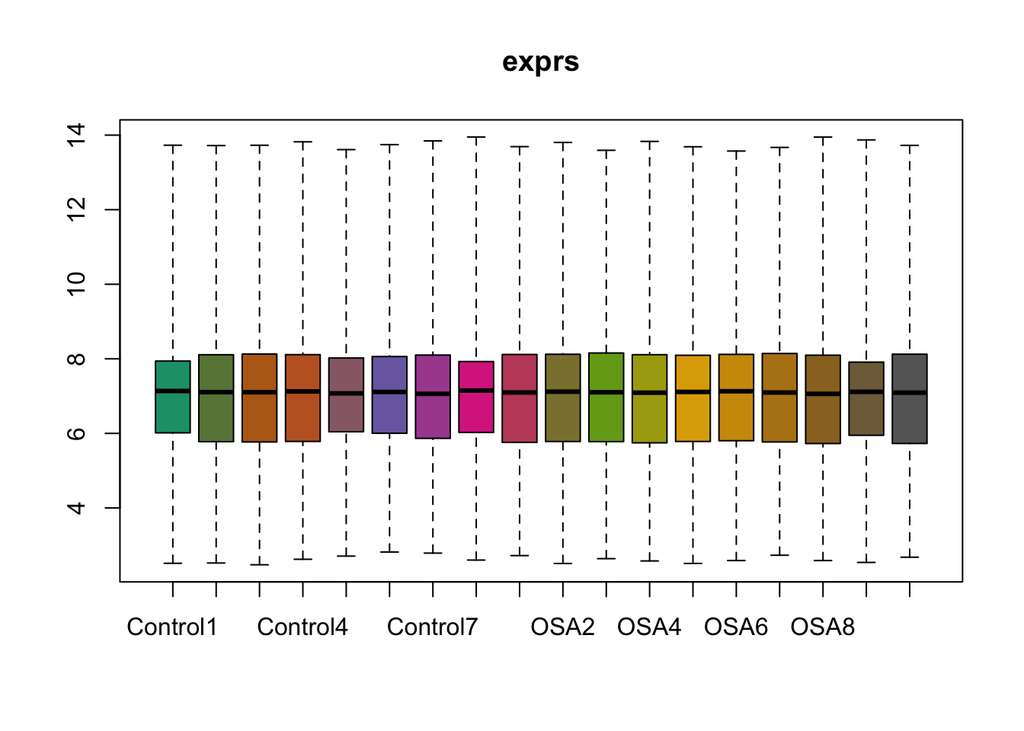

```r
boxplot(normData)
```

While the distributions are similar, they are not identical despite the fact that RMA includes quantile normalization.

The data is now ready for differential expression analysis.

## limma

Linear model for micro-arrays, limma package, is developed for analysis of gene expression microarrays. It also fit classic model. Linear models are a general class of models for continuous data. There are other Bioconductor packages dealing with count data such as PESeek, PESeek2, Estar.

A lot of these packages deal feature (gene) and we want to find genes that are differentially expressed. Most gene expression data are with 10K+ genes with relatively few samples. We typically assess gene expression and variance of the gene.

The design of the experiment tells us meta information of the experimnet such as time, what samples, paired design and etc.

```r
#BiocManager::install("limma")
#BiocManager::install("leukemiasEset")
library(limma)
library(leukemiasEset)
data(leukemiasEset)
leukemiasEset
```

```
## ExpressionSet (storageMode: lockedEnvironment)
## assayData: 20172 features, 60 samples
##   element names: exprs, se.exprs
## protocolData
##   sampleNames: GSM330151.CEL GSM330153.CEL ... GSM331677.CEL (60 total)
##   varLabels: ScanDate
##   varMetadata: labelDescription
## phenoData
##   sampleNames: GSM330151.CEL GSM330153.CEL ... GSM331677.CEL (60 total)
##   varLabels: Project Tissue ... Subtype (5 total)
##   varMetadata: labelDescription
## featureData: none
## experimentData: use 'experimentData(object)'
## Annotation: genemapperhgu133plus2
```

```r
table(leukemiasEset$LeukemiaType)
```

```
##
## ALL AML CLL CML NoL
##  12  12  12  12  12
```

Here, we will only discuss two groups: ALL, and NoL group.

```r
ourData <- leukemiasEset[, leukemiasEset$LeukemiaType %in% c("ALL","NoL")]
ourData$LeukemiaType
```

```
##  [1] ALL ALL ALL ALL ALL ALL ALL ALL ALL ALL ALL ALL NoL NoL NoL NoL NoL NoL NoL
## [20] NoL NoL NoL NoL NoL
## Levels: ALL AML CLL CML NoL
```

This data contains levels that are not present in the subset.

```r
ourData$LeukemiaType <- factor(ourData$LeukemiaType)
ourData$LeukemiaType
```

```
##  [1] ALL ALL ALL ALL ALL ALL ALL ALL ALL ALL ALL ALL NoL NoL NoL NoL NoL NoL NoL
## [20] NoL NoL NoL NoL NoL
## Levels: ALL NoL
```

#### Setup design matrix

Setting up design matrix is a general statistical task

```r
design <- model.matrix(~ ourData$LeukemiaType)
head(design)
```

```
##   (Intercept) ourData$LeukemiaTypeNoL
## 1           1                       0
## 2           1                       0
## 3           1                       0
## 4           1                       0
## 5           1                       0
## 6           1                       0
```

Intercept is the average gene expression for a given gene across ALL samples. The second column is the difference in gene expression between NOL and ALL. If this parameter is equal to 0, the gene is not differentially expressed.

First thing to do with limma is we fit basic model with design. In statistics, we separate the model from the hypothesis. The model tells us that we have 24 samples and there are two groups. The hypothesis here is that there are no differences between ALL and NoL.

```r
fit <- lmFit(ourData, design)
fit <- eBayes(fit)
topTable(fit)
```

```
## Removing intercept from test coefficients
```

```
##                    logFC  AveExpr        t      P.Value    adj.P.Val        B
## ENSG00000163751 4.089587 5.819472 22.51729 9.894742e-18 1.733025e-13 30.15253
## ENSG00000104043 4.519488 5.762115 21.98550 1.718248e-17 1.733025e-13 29.65066
## ENSG00000008394 5.267835 7.482490 20.08250 1.374231e-16 9.240332e-13 27.73589
## ENSG00000165140 3.206807 6.560163 19.41855 2.959391e-16 1.492421e-12 27.02056
## ENSG00000204103 4.786273 7.774809 19.04041 4.628812e-16 1.867448e-12 26.60138
## ENSG00000145569 2.845963 5.958707 18.46886 9.239404e-16 3.067090e-12 25.95084
## ENSG00000038427 5.047670 6.496822 18.35375 1.064328e-15 3.067090e-12 25.81729
## ENSG00000173391 4.282498 5.293222 17.89645 1.881511e-15 4.744229e-12 25.27803
## ENSG00000138449 5.295928 6.999716 17.79655 2.134448e-15 4.784010e-12 25.15836
## ENSG00000105352 2.521351 7.054018 17.62423 2.657074e-15 5.359850e-12 24.95031
```

We asked whether or not two groups have differential gene expression, therefore, we only have one result.

The fold change here means fold change from NoL to ALL.

To check if our interpretation is valid,

```r
topTable(fit, n=1)
```

```
## Removing intercept from test coefficients
```

```
##                    logFC  AveExpr        t      P.Value    adj.P.Val        B
## ENSG00000163751 4.089587 5.819472 22.51729 9.894742e-18 1.733025e-13 30.15253
```

```r
genename <- rownames(topTable(fit,n=1))
```

```
## Removing intercept from test coefficients
```

```r
typeMean <- tapply(exprs(ourData)[genename,], ourData$LeukemiaType, mean)
typeMean
```

```
##      ALL      NoL
## 3.774678 7.864265
```

```r
typeMean["NoL"] - typeMean["ALL"]
```

```
##      NoL
## 4.089587
```

What we did here is known as moderated gene statistic, because we have estimated variability of the data in different way from a normal t statistic.

Let's go back and refit this model to explain what contrast we are interested in.

```r
design2 <- model.matrix(~ourData$LeukemiaType - 1)
head(design2)
```

```
##   ourData$LeukemiaTypeALL ourData$LeukemiaTypeNoL
## 1                       1                       0
## 2                       1                       0
## 3                       1                       0
## 4                       1                       0
## 5                       1                       0
## 6                       1                       0
```

```r
colnames(design2) <- c("ALL","NoL")
design2
```

```
##    ALL NoL
## 1    1   0
## 2    1   0
## 3    1   0
## 4    1   0
## 5    1   0
## 6    1   0
## 7    1   0
## 8    1   0
## 9    1   0
## 10   1   0
## 11   1   0
## 12   1   0
## 13   0   1
## 14   0   1
## 15   0   1
## 16   0   1
## 17   0   1
## 18   0   1
## 19   0   1
## 20   0   1
## 21   0   1
## 22   0   1
## 23   0   1
## 24   0   1
## attr(,"assign")
## [1] 1 1
## attr(,"contrasts")
## attr(,"contrasts")$`ourData$LeukemiaType`
## [1] "contr.treatment"
```

```r
fit2 <- lmFit(ourData, design2)
contrast.matrix <- makeContrasts("ALL-NoL", levels=design2)
contrast.matrix
```

```
##       Contrasts
## Levels ALL-NoL
##    ALL       1
##    NoL      -1
```

Here, we made contrast. A contrast is a hypothesis, and we call makeContrasts(). In the design, we made a contrast that is ALL minus NoL. We allow NoL as a reference level.

This result tells us whether two parameters with this linear combination is equal to zero. Now we have contrast, we are going to do contrasts.fit()

```r
fit2C <- contrasts.fit(fit2, contrast.matrix)
fit2C <- eBayes(fit2C)
topTable(fit2C)
```

```
##                     logFC  AveExpr         t      P.Value    adj.P.Val        B
## ENSG00000163751 -4.089587 5.819472 -22.51729 9.894742e-18 1.733025e-13 30.15253
## ENSG00000104043 -4.519488 5.762115 -21.98550 1.718248e-17 1.733025e-13 29.65066
## ENSG00000008394 -5.267835 7.482490 -20.08250 1.374231e-16 9.240332e-13 27.73589
## ENSG00000165140 -3.206807 6.560163 -19.41855 2.959391e-16 1.492421e-12 27.02056
## ENSG00000204103 -4.786273 7.774809 -19.04041 4.628812e-16 1.867448e-12 26.60138
## ENSG00000145569 -2.845963 5.958707 -18.46886 9.239404e-16 3.067090e-12 25.95084
## ENSG00000038427 -5.047670 6.496822 -18.35375 1.064328e-15 3.067090e-12 25.81729
## ENSG00000173391 -4.282498 5.293222 -17.89645 1.881511e-15 4.744229e-12 25.27803
## ENSG00000138449 -5.295928 6.999716 -17.79655 2.134448e-15 4.784010e-12 25.15836
## ENSG00000105352 -2.521351 7.054018 -17.62423 2.657074e-15 5.359850e-12 24.95031
```

## minfi

minifi package is a package for handling data from DNA methylation microarrays. In a single cell, methylation state is a binary or it actually has three values because we have two copies of each chromosome. Outcome of methylation can be thought as percentage or beta values between 0 and 1. The DNA methylation is to understand how DNA methylation changes or associated with a phenotype status.

A popular platform for DNA methylation is the 450K microarray.

```r
library(minfi)
```

[output not shown]

```r
library(GEOquery)
```

Acute mania DNA methylation changes

```r
#getGEOSuppFiles("GSE68777")
#untar("GSE68777/GSE68777_RAW.tar", exdir ="GSE68777/idat")
head(list.files("GSE68777/idat",pattern="idat"))
```

```
## [1] "GSM1681154_5958091019_R03C02_Grn.idat"
## [2] "GSM1681154_5958091019_R03C02_Red.idat"
## [3] "GSM1681155_5935446005_R05C01_Grn.idat"
## [4] "GSM1681155_5935446005_R05C01_Red.idat"
## [5] "GSM1681156_5958091020_R01C01_Grn.idat"
## [6] "GSM1681156_5958091020_R01C01_Red.idat"
```

We get one file for each color channel, so two files per sample.

```r
#idatFiles <- list.files("GSE68777/idat", pattern = "idat.gz$", full = TRUE)
#sapply(idatFiles, gunzip, overwrite = TRUE)
#rgSet <- read.450k.exp("GSE68777/idat") # defunct
rgSet <- read.metharray.exp("GSE68777/idat")
rgSet
```

```
## class: RGChannelSet
## dim: 622399 40
## metadata(0):
## assays(2): Green Red
## rownames(622399): 10600313 10600322 ... 74810490 74810492
## rowData names(0):
## colnames(40): GSM1681154_5958091019_R03C02 GSM1681155_5935446005_R05C01
##   ... GSM1681192_5958091020_R02C02 GSM1681193_5935403032_R04C01
## colData names(0):
## Annotation
##   array: IlluminaHumanMethylation450k
##   annotation: ilmn12.hg19
```

```r
pData(rgSet)
```

```
## DataFrame with 40 rows and 0 columns
```

```r
sampleNames(rgSet)
```

```
##  [1] "GSM1681154_5958091019_R03C02" "GSM1681155_5935446005_R05C01"
##  [3] "GSM1681156_5958091020_R01C01" "GSM1681157_5958091020_R03C02"
##  [5] "GSM1681158_5935403032_R05C01" "GSM1681159_5958091019_R04C02"
##  [7] "GSM1681160_5935446005_R06C01" "GSM1681161_5958091020_R02C01"
##  [9] "GSM1681162_5958091020_R04C02" "GSM1681163_5935403032_R06C01"
## [11] "GSM1681164_5935446005_R01C02" "GSM1681165_5958091020_R03C01"
## [13] "GSM1681166_5958091020_R05C02" "GSM1681167_5935403032_R01C02"
## [15] "GSM1681168_5958091019_R06C02" "GSM1681169_5935446005_R02C02"
## [17] "GSM1681170_5958091020_R04C01" "GSM1681171_5958091020_R06C02"
## [19] "GSM1681172_5935403032_R02C02" "GSM1681173_5958091019_R05C01"
## [21] "GSM1681174_5935446005_R01C01" "GSM1681175_5935446005_R03C02"
## [23] "GSM1681176_5958091020_R05C01" "GSM1681177_5935403032_R01C01"
## [25] "GSM1681178_5935403032_R03C02" "GSM1681179_5958091019_R06C01"
## [27] "GSM1681180_5935446005_R02C01" "GSM1681181_5935446005_R04C02"
## [29] "GSM1681182_5958091020_R06C01" "GSM1681183_5935403032_R02C01"
## [31] "GSM1681184_5958091019_R01C02" "GSM1681185_5935446005_R03C01"
## [33] "GSM1681186_5935446005_R05C02" "GSM1681187_5958091020_R01C02"
## [35] "GSM1681188_5935403032_R03C01" "GSM1681189_5958091019_R02C02"
## [37] "GSM1681190_5935446005_R04C01" "GSM1681191_5935446005_R06C02"
## [39] "GSM1681192_5958091020_R02C02" "GSM1681193_5935403032_R04C01"
```

To get phenotype data and other information, we need to download original GEO data.

```r
geoMat <- getGEO("GSE68777")
```

```
## Found 1 file(s)
```

```
## GSE68777_series_matrix.txt.gz
```

```
## File stored at:
```

```
## /var/folders/1n/hgn96y1n2tdfcvqkdsv34cvr0000gn/T//RtmpwOjvPf/GPL13534.soft
```

```r
geoMat
```

```
## $GSE68777_series_matrix.txt.gz
## ExpressionSet (storageMode: lockedEnvironment)
## assayData: 485512 features, 40 samples
##   element names: exprs
## protocolData: none
## phenoData
##   sampleNames: GSM1681154 GSM1681155 ... GSM1681193 (40 total)
##   varLabels: title geo_accession ... Sex:ch1 (36 total)
##   varMetadata: labelDescription
## featureData
##   featureNames: cg00000029 cg00000108 ... ch.X.98007042R (485512 total)
##   fvarLabels: ID Name ... SPOT_ID (37 total)
##   fvarMetadata: Column Description labelDescription
## experimentData: use 'experimentData(object)'
##   pubMedIds: 26147665
## Annotation: GPL13534
```

```r
pD.all <- pData(geoMat[[1]])
pD <- pD.all[, c("title","geo_accession","characteristics_ch1.1","characteristics_ch1.2")]
head(pD)
```

```
##                        title geo_accession characteristics_ch1.1
## GSM1681154 5958091019_R03C02    GSM1681154      diagnosis: Mania
## GSM1681155 5935446005_R05C01    GSM1681155      diagnosis: Mania
## GSM1681156 5958091020_R01C01    GSM1681156        diagnosis: Ctr
## GSM1681157 5958091020_R03C02    GSM1681157        diagnosis: Ctr
## GSM1681158 5935403032_R05C01    GSM1681158      diagnosis: Mania
## GSM1681159 5958091019_R04C02    GSM1681159      diagnosis: Mania
##            characteristics_ch1.2
## GSM1681154           Sex: Female
## GSM1681155           Sex: Female
## GSM1681156             Sex: Male
## GSM1681157           Sex: Female
## GSM1681158           Sex: Female
## GSM1681159             Sex: Male
```

```r
names(pD)[c(3,4)] <- c("group","sex")
pD$group <- sub("^diagnosis: ","",pD$group)
pD$sex <- sub("^Sex: ","",pD$sex)
head(pD)
```

```
##                        title geo_accession group    sex
## GSM1681154 5958091019_R03C02    GSM1681154 Mania Female
## GSM1681155 5935446005_R05C01    GSM1681155 Mania Female
## GSM1681156 5958091020_R01C01    GSM1681156   Ctr   Male
## GSM1681157 5958091020_R03C02    GSM1681157   Ctr Female
## GSM1681158 5935403032_R05C01    GSM1681158 Mania Female
## GSM1681159 5958091019_R04C02    GSM1681159 Mania   Male
```

Now we will merge empty phenotype data of rgSet with pD.

```r
sampleNames(rgSet) <- sub(".*_5","5",sampleNames(rgSet))
rownames(pD) <- pD$title
pD <- pD[sampleNames(rgSet),]
head(sampleNames(rgSet))
```

```
## [1] "5958091019_R03C02" "5935446005_R05C01" "5958091020_R01C01"
## [4] "5958091020_R03C02" "5935403032_R05C01" "5958091019_R04C02"
```

```r
head(pD)
```

```
##                               title geo_accession group    sex
## 5958091019_R03C02 5958091019_R03C02    GSM1681154 Mania Female
## 5935446005_R05C01 5935446005_R05C01    GSM1681155 Mania Female
## 5958091020_R01C01 5958091020_R01C01    GSM1681156   Ctr   Male
## 5958091020_R03C02 5958091020_R03C02    GSM1681157   Ctr Female
## 5935403032_R05C01 5935403032_R05C01    GSM1681158 Mania Female
## 5958091019_R04C02 5958091019_R04C02    GSM1681159 Mania   Male
```

```r
pData(rgSet) <- DataFrame(pD) # supposedly pData(rgSet) <- pD won't work and might be a bug as it will accept DataFrame not data.frame which is a R object.
rgSet
```

```
## class: RGChannelSet
## dim: 622399 40
## metadata(0):
## assays(2): Green Red
## rownames(622399): 10600313 10600322 ... 74810490 74810492
## rowData names(0):
## colnames(40): 5958091019_R03C02 5935446005_R05C01 ... 5958091020_R02C02
##   5935403032_R04C01
## colData names(4): title geo_accession group sex
## Annotation
##   array: IlluminaHumanMethylation450k
##   annotation: ilmn12.hg19
```

First thing to do with microarray data is to normalize it.

```r
grSet <- preprocessQuantile(rgSet)
```

```
## [preprocessQuantile] Mapping to genome.
```

```
## [preprocessQuantile] Fixing outliers.
```

```
## [preprocessQuantile] Quantile normalizing.
```

```r
grSet
```

```
## class: GenomicRatioSet
## dim: 485512 40
## metadata(0):
## assays(2): M CN
## rownames(485512): cg13869341 cg14008030 ... cg08265308 cg14273923
## rowData names(0):
## colnames(40): 5958091019_R03C02 5935446005_R05C01 ... 5958091020_R02C02
##   5935403032_R04C01
## colData names(7): title geo_accession ... yMed predictedSex
## Annotation
##   array: IlluminaHumanMethylation450k
##   annotation: ilmn12.hg19
## Preprocessing
##   Method: Raw (no normalization or bg correction)
##   minfi version: 1.32.0
##   Manifest version: 0.4.0
```

```r
granges(grSet)
```

```
## GRanges object with 485512 ranges and 0 metadata columns:
##              seqnames    ranges strand
##                 <Rle> <IRanges>  <Rle>
##   cg13869341     chr1     15865      *
##   cg14008030     chr1     18827      *
##   cg12045430     chr1     29407      *
##   cg20826792     chr1     29425      *
##   cg00381604     chr1     29435      *
##          ...      ...       ...    ...
##   cg17939569     chrY  27009430      *
##   cg13365400     chrY  27210334      *
##   cg21106100     chrY  28555536      *
##   cg08265308     chrY  28555550      *
##   cg14273923     chrY  28555912      *
##   -------
##   seqinfo: 24 sequences from hg19 genome; no seqlengths
```

granges object detail the C in the forward strand where c may or may not be methylated. CpG tend to cluster into CpG islands. Whether CpG is inside the CpG island, nearby the island (CpG shores) or far from CpG island (open sea CpG) can be accessed by getIslandStatus().

```r
head(getIslandStatus(grSet))
```

```
## [1] "OpenSea" "OpenSea" "Island"  "Island"  "Island"  "OpenSea"
```

Now that we normalized the data, we can get Beta value (percentage), and then we are ready for analysis.

```r
getBeta(grSet)[1:3,1:3]
```

```
##            5958091019_R03C02 5935446005_R05C01 5958091020_R01C01
## cg13869341         0.7485333         0.7696497         0.7322275
## cg14008030         0.5300410         0.5893653         0.6044354
## cg12045430         0.0912596         0.1007678         0.1057603
```

We can use limma package (differently expressed) bumphunter() in bumphunter package (cluster trend).

## Count-based RNA-seq analysis

We imagine that we have summarized data at a feature level. So for each sample, we know how many reads match your particular feature (summarized in interger).

```r
library(airway)
data(airway)
airway
```

```
## class: RangedSummarizedExperiment
## dim: 64102 8
## metadata(1): ''
## assays(1): counts
## rownames(64102): ENSG00000000003 ENSG00000000005 ... LRG_98 LRG_99
## rowData names(0):
## colnames(8): SRR1039508 SRR1039509 ... SRR1039520 SRR1039521
## colData names(9): SampleName cell ... Sample BioSample
```

```r
assay(airway,"counts")[1:3,1:3]
```

```
##                 SRR1039508 SRR1039509 SRR1039512
## ENSG00000000003        679        448        873
## ENSG00000000005          0          0          0
## ENSG00000000419        467        515        621
```

```r
airway$dex # variable whether sample belongs to treatment or untreatment group.
```

```
## [1] untrt trt   untrt trt   untrt trt   untrt trt
## Levels: trt untrt
```

reference level is not untreated so,

```r
airway$dex <- relevel(airway$dex, "untrt")
airway$dex
```

```
## [1] untrt trt   untrt trt   untrt trt   untrt trt
## Levels: untrt trt
```

This summarized experiment contains a rich information on what the gene model is.

```r
granges(airway)
```

```
## GRangesList object of length 64102:
## $ENSG00000000003
## GRanges object with 17 ranges and 2 metadata columns:
##        seqnames            ranges strand |   exon_id       exon_name
##           <Rle>         <IRanges>  <Rle> | <integer>     <character>
##    [1]        X 99883667-99884983      - |    667145 ENSE00001459322
##    [2]        X 99885756-99885863      - |    667146 ENSE00000868868
##    [3]        X 99887482-99887565      - |    667147 ENSE00000401072
##    [4]        X 99887538-99887565      - |    667148 ENSE00001849132
##    [5]        X 99888402-99888536      - |    667149 ENSE00003554016
##    ...      ...               ...    ... .       ...             ...
##   [13]        X 99890555-99890743      - |    667156 ENSE00003512331
##   [14]        X 99891188-99891686      - |    667158 ENSE00001886883
##   [15]        X 99891605-99891803      - |    667159 ENSE00001855382
##   [16]        X 99891790-99892101      - |    667160 ENSE00001863395
##   [17]        X 99894942-99894988      - |    667161 ENSE00001828996
##   -------
##   seqinfo: 722 sequences (1 circular) from an unspecified genome
##
## ...
## <64101 more elements>
```

Getting this gene by sample count matrix is not easy. To do it, we need to get annotation or we have to select some features and select a way to count overlaps. We particularly be careful when a gene has a multiple transcript.

As a starting point, we will show how we fit statistical model similar to what we have seen in limma package. Two packages for analyzing this data is edgeR, or DESeq2.

Both fit generalized linear model based on the negative binomial distribution, but they differ in how they implement these models (typically how they estimate variability).

```r
#BiocManager::install("edgeR")
library(edgeR)
```

We first have to take out data from summarized experiment and converted into limma class.

```r
dge <- DGEList(counts = assay(airway,"counts"),
               group = airway$dex)
dge$samples
```

```
##            group lib.size norm.factors
## SRR1039508 untrt 20637971            1
## SRR1039509   trt 18809481            1
## SRR1039512 untrt 25348649            1
## SRR1039513   trt 15163415            1
## SRR1039516 untrt 24448408            1
## SRR1039517   trt 30818215            1
## SRR1039520 untrt 19126151            1
## SRR1039521   trt 21164133            1
```

There are two additional information that are nice to add to dge set, 1) Pheno data, and 2) which gene actually profiled in the experiment.

Pheno data comes into the gList through the samples log. However, we cannot give sample information directly to the dge list constructor. Therefore, to take out additional data on these additional co-variance, we have to create a new data frame and put samples there.

```r
dge$samples <- merge(dge$samples,
                     as.data.frame(colData(airway)),
                     by=0)
dge$samples
```

```
##    Row.names group lib.size norm.factors SampleName    cell   dex albut
## 1 SRR1039508 untrt 20637971            1 GSM1275862  N61311 untrt untrt
## 2 SRR1039509   trt 18809481            1 GSM1275863  N61311   trt untrt
## 3 SRR1039512 untrt 25348649            1 GSM1275866 N052611 untrt untrt
## 4 SRR1039513   trt 15163415            1 GSM1275867 N052611   trt untrt
## 5 SRR1039516 untrt 24448408            1 GSM1275870 N080611 untrt untrt
## 6 SRR1039517   trt 30818215            1 GSM1275871 N080611   trt untrt
## 7 SRR1039520 untrt 19126151            1 GSM1275874 N061011 untrt untrt
## 8 SRR1039521   trt 21164133            1 GSM1275875 N061011   trt untrt
##          Run avgLength Experiment    Sample    BioSample
## 1 SRR1039508       126  SRX384345 SRS508568 SAMN02422669
## 2 SRR1039509       126  SRX384346 SRS508567 SAMN02422675
## 3 SRR1039512       126  SRX384349 SRS508571 SAMN02422678
## 4 SRR1039513        87  SRX384350 SRS508572 SAMN02422670
## 5 SRR1039516       120  SRX384353 SRS508575 SAMN02422682
## 6 SRR1039517       126  SRX384354 SRS508576 SAMN02422673
## 7 SRR1039520       101  SRX384357 SRS508579 SAMN02422683
## 8 SRR1039521        98  SRX384358 SRS508580 SAMN02422677
```

Now we have a rich pheno data set. We can give a gene name.

```r
dge$genes
```

```r
dge$genes <- data.frame(name=names(rowRanges(airway)),
                        stringsAsFactors = FALSE)
head(dge$genes)
```

```
##              name
## 1 ENSG00000000003
## 2 ENSG00000000005
## 3 ENSG00000000419
## 4 ENSG00000000457
## 5 ENSG00000000460
## 6 ENSG00000000938
```

Different gene names in rows and put it into data.frame.

To calculate RPKN, we use the total number of map reads. We have different library sizes, different sequencing depths, and different samples. However, the best way to do this is not just to count how many reads.

```r
dge <- calcNormFactors(dge)
dge$samples
```

```
##    Row.names group lib.size norm.factors SampleName    cell   dex albut
## 1 SRR1039508 untrt 20637971    1.0553567 GSM1275862  N61311 untrt untrt
## 2 SRR1039509   trt 18809481    1.0291947 GSM1275863  N61311   trt untrt
## 3 SRR1039512 untrt 25348649    0.9832690 GSM1275866 N052611 untrt untrt
## 4 SRR1039513   trt 15163415    0.9490081 GSM1275867 N052611   trt untrt
## 5 SRR1039516 untrt 24448408    1.0255871 GSM1275870 N080611 untrt untrt
## 6 SRR1039517   trt 30818215    0.9729022 GSM1275871 N080611   trt untrt
## 7 SRR1039520 untrt 19126151    1.0308785 GSM1275874 N061011 untrt untrt
## 8 SRR1039521   trt 21164133    0.9592055 GSM1275875 N061011   trt untrt
##          Run avgLength Experiment    Sample    BioSample
## 1 SRR1039508       126  SRX384345 SRS508568 SAMN02422669
## 2 SRR1039509       126  SRX384346 SRS508567 SAMN02422675
## 3 SRR1039512       126  SRX384349 SRS508571 SAMN02422678
## 4 SRR1039513        87  SRX384350 SRS508572 SAMN02422670
## 5 SRR1039516       120  SRX384353 SRS508575 SAMN02422682
## 6 SRR1039517       126  SRX384354 SRS508576 SAMN02422673
## 7 SRR1039520       101  SRX384357 SRS508579 SAMN02422683
## 8 SRR1039521        98  SRX384358 SRS508580 SAMN02422677
```

We, then, estimate dispersion of variability of the data. We are going to estimate a tagwise dispersion. In order to do that, we first have to estimate common dispersion.

```r
dge <- estimateGLMCommonDisp(dge)

dge <- estimateTagwiseDisp(dge)
```

Now we estimate dispersion parameter, and ready to do model fitting.

```r
design <- model.matrix(~dge$samples$group)
head(design)
```

```
##   (Intercept) dge$samples$grouptrt
## 1           1                    0
## 2           1                    1
## 3           1                    0
## 4           1                    1
## 5           1                    0
## 6           1                    1
```

```r
fit <- glmFit(dge, design)
```

Then we see which gene is most significant.

```r
lrt <- glmLRT(fit, coef=2)
topTags(lrt)
```

```
## Coefficient:  dge$samples$grouptrt
##                            name     logFC   logCPM       LR       PValue
## ENSG00000152583 ENSG00000152583  4.584937 5.537322 290.7460 3.419868e-65
## ENSG00000109906 ENSG00000109906  7.133046 4.165802 200.5542 1.580839e-45
## ENSG00000179593 ENSG00000179593 10.100388 1.669921 177.3188 1.865773e-40
## ENSG00000101347 ENSG00000101347  3.842553 9.207618 171.3687 3.717437e-39
## ENSG00000189221 ENSG00000189221  3.288879 6.769544 164.7086 1.059154e-37
## ENSG00000250978 ENSG00000250978  6.166190 1.413689 163.2678 2.186321e-37
## ENSG00000179094 ENSG00000179094  3.167796 5.178177 160.2827 9.814863e-37
## ENSG00000120129 ENSG00000120129  2.932872 7.311047 159.3714 1.552386e-36
## ENSG00000096060 ENSG00000096060  3.921387 6.899335 157.3975 4.190752e-36
## ENSG00000178695 ENSG00000178695 -2.515047 6.959199 134.9583 3.371850e-31
##                          FDR
## ENSG00000152583 2.192204e-60
## ENSG00000109906 5.066747e-41
## ENSG00000179593 3.986659e-36
## ENSG00000101347 5.957378e-35
## ENSG00000189221 1.357877e-33
## ENSG00000250978 2.335793e-33
## ENSG00000179094 8.987891e-33
## ENSG00000120129 1.243888e-32
## ENSG00000096060 2.984840e-32
## ENSG00000178695 2.161423e-27
```

Now we are going to see how we do this in DESeq2

```r
library(DESeq2)
```

unlike EdgeR we can convert directly from summarized experiment.

```r
dds <- DESeqDataSet(airway, design = ~ dex)
```

Now we need to store design matrix inside the data object. Once it is setup, it is easy to run the fit.

```r
dds <- DESeq(dds)
```

We can get results by

```r
res <- results(dds)
res <- res[order(res$padj),]
res
```

```
## log2 fold change (MLE): dex trt vs untrt
## Wald test p-value: dex trt vs untrt
## DataFrame with 64102 rows and 6 columns
##                         baseMean   log2FoldChange              lfcSE
##                        <numeric>        <numeric>          <numeric>
## ENSG00000152583 997.439773207048 4.60252604913628  0.211770756981607
## ENSG00000148175  11193.718773887 1.45146597545842 0.0848248918368829
## ENSG00000179094 776.596665468835 3.18385763641245  0.201515441180826
## ENSG00000134686 2737.98198594824 1.38714107233632 0.0915842458412019
## ENSG00000125148   3656.252782247 2.20343889385752  0.147408663474503
## ...                          ...              ...                ...
## LRG_94                         0               NA                 NA
## LRG_96                         0               NA                 NA
## LRG_97                         0               NA                 NA
## LRG_98                         0               NA                 NA
## LRG_99                         0               NA                 NA
##                             stat                pvalue                  padj
##                        <numeric>             <numeric>             <numeric>
## ENSG00000152583 21.7335297598999 9.88999144305974e-105 1.83904390883696e-100
## ENSG00000148175 17.1113212646303  1.22195865249377e-65  1.13611605715608e-61
## ENSG00000179094 15.7995715750411  3.13238099525437e-56   1.9415541535585e-52
## ENSG00000134686 15.1460664396526  8.04391341624933e-52  3.73941424937891e-48
## ENSG00000125148 14.9478249237274  1.60919813440635e-50  5.98460786185722e-47
## ...                          ...                   ...                   ...
## LRG_94                        NA                    NA                    NA
## LRG_96                        NA                    NA                    NA
## LRG_97                        NA                    NA                    NA
## LRG_98                        NA                    NA                    NA
## LRG_99                        NA                    NA                    NA
```

sessionInfo()